# R Notebook

```r
library(plyr)
library(readr)
library(dplyr)
library(caret)
library(ggplot2)
library(repr)
library(car)
```

¿Cúal es el esta ́ıstico del test correspondiente y cu ́al es su distribci ́on bajo H0 ?

(Beta estimado - 0)/( raiz(var(Beta estimado) ) ) tiene distribucion Tstudent n-2 (porque son 2 parametros los que estoy estimando)

¿Cuanto vale este estad́ıstico para estos datos? 12.27

3. Considerar las hip ́otesis H0 : α = 10 vs. H1 : α > 10. ¿Hay evidencia suficiente para rechazar H0 a nivel 0,05?

(alpha estimado - 10) / sd ~ Tstudent n-2

luego en nuestro caso como alpha estimado es 12.34, obtenemos 2.34 / (2.64) = 0.886 luego como qt(0.95, 30) = 1.69 > 0.886 no rechazo h0

Hallar el p−valor.

p-valor seria 1-pt(0.886, 30)

d ) Hallar un intervalo de confianza para α de nivel 0,95.

[xbarra - tstudent(n-2, 1-alpha/2) * sd; xbarra + tstudent(n-2, 1-alpha/2) * sd] como qt(0.975, 30) = 2.04

[12.34 - 2.04 * 2.64; 12.34 + 2.04 * 2.64]

¿Cúanto vale el R2 en este caso y ćomo interpréıa este valor en t́erminos de las variables del enunciado?

el 83% de la variabilidad de tu variable Y (que mide el tiempo) es explicada por el modelo en función del peso

```r
df = read.csv("glakes.csv")
```

```r
mod = lm(data=df, Time~Tonnage)
summary(mod)
```

```
Call:
lm(formula = Time ~ Tonnage, data = df)

Residuals:
    Min      1Q  Median      3Q     Max
-23.882  -6.397  -1.261   5.931  21.850

Coefficients:
             Estimate Std. Error t value Pr(>|t|)
(Intercept) 12.344707   2.642633   4.671 6.32e-05 ***
Tonnage      0.006518   0.000531  12.275 5.22e-13 ***
---
Signif. codes:  0 ‘***’ 0.001 ‘**’ 0.01 ‘*’ 0.05 ‘.’ 0.1 ‘ ’ 1

Residual standard error: 10.7 on 29 degrees of freedom
Multiple R-squared:  0.8386,    Adjusted R-squared:  0.833
F-statistic: 150.7 on 1 and 29 DF,  p-value: 5.218e-13
```

```r
y = predict(mod, df)
```

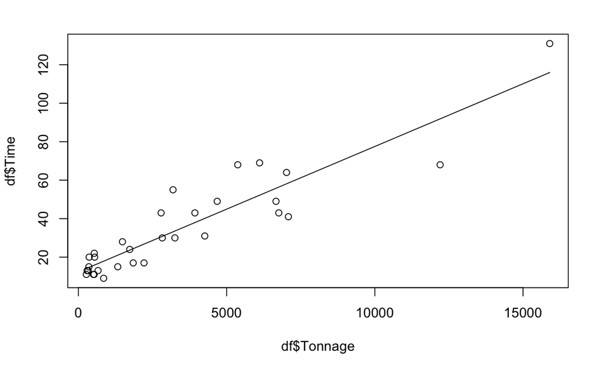

```r
plot(df$Tonnage, df$Time)
lines(df$Tonnage, y)
```

```r
pt(2.24,30)
```

```
[1] 0.9836739
```

```r
coef = mod$coefficients
s = 2.6426
xt = as.numeric(df$Tonnage)
Test = (t(xt) * coef - t(xt)*10)/(sqrt(s**2 * t(xt) ) )
```

```r
A = rnorm(100, 0, 1)
B = rnorm(100, 0.1, 1)
var.test(A, B, alternative = "two.sided") # test para sigma A = sigma B
```

```
    F test to compare two variances

data:  A and B
F = 0.7341, num df = 99, denom df = 99, p-value = 0.1258
alternative hypothesis: true ratio of variances is not equal to 1
95 percent confidence interval:
 0.4939321 1.0910420
sample estimates:
ratio of variances
         0.7340985
```

```r
t.test(A,B, var.equal = TRUE) # test para mu A = mu B
```

```
    Two Sample t-test

data:  A and B
t = -2.3044, df = 198, p-value = 0.02224
alternative hypothesis: true difference in means is not equal to 0
95 percent confidence interval:
 -0.62911164 -0.04890297
sample estimates:
 mean of x  mean of y
-0.1182913  0.2207160
```

```r
shapiro.test(A) # test de normalidad
```

```
    Shapiro-Wilk normality test

data:  A
W = 0.98631, p-value = 0.3926
```

```r
errorCuadraticoMedio = function(y, yhat){
  return(mean((y-yhat)**2))
}
```

```r
looLM = function(datos, evaluador){
  errores = c()
  datos$indice = 1:nrow(datos)
  for (i in 1:nrow(datos)){
    train = datos[datos$indice != i,]
    test = datos[datos$indice == i,]
    modelo = lm(data=train, Time ~ Tonnage)
    yhatTrain =  predict(modelo)
    yhatTest =  predict(modelo, newdata = test )
    errores[i] = evaluador(test$Time, yhatTest)
  }
  return(mean(errores))
}
```

```r
looLM(df, errorCuadraticoMedio)
```

```
[1] 141.1349
```

EJEMPLO MTCARS Ridge es alpha = 0, lasso es alpha =1

```r
y <- mtcars$hp

#define matrix of predictor variables
x <- data.matrix(mtcars[, c('mpg', 'wt', 'drat', 'qsec')])
library(glmnet)

#fit ridge regression model
model <- glmnet(x, y, alpha = 0)

#view summary of model
summary(model)
```

```
          Length Class     Mode
a0        100    -none-    numeric
beta      400    dgCMatrix S4
df        100    -none-    numeric
dim         2    -none-    numeric
lambda    100    -none-    numeric
dev.ratio 100    -none-    numeric
nulldev     1    -none-    numeric
npasses     1    -none-    numeric
jerr        1    -none-    numeric
offset      1    -none-    logical
call        4    -none-    call
nobs        1    -none-    numeric
```

```r
cv_model <- cv.glmnet(x, y, alpha = 0, lambda=seq(0,19,0.01))

#find optimal lambda value that minimizes test MSE
best_lambda <- cv_model$lambda.min
best_lambda
```

```
[1] 8.47
```

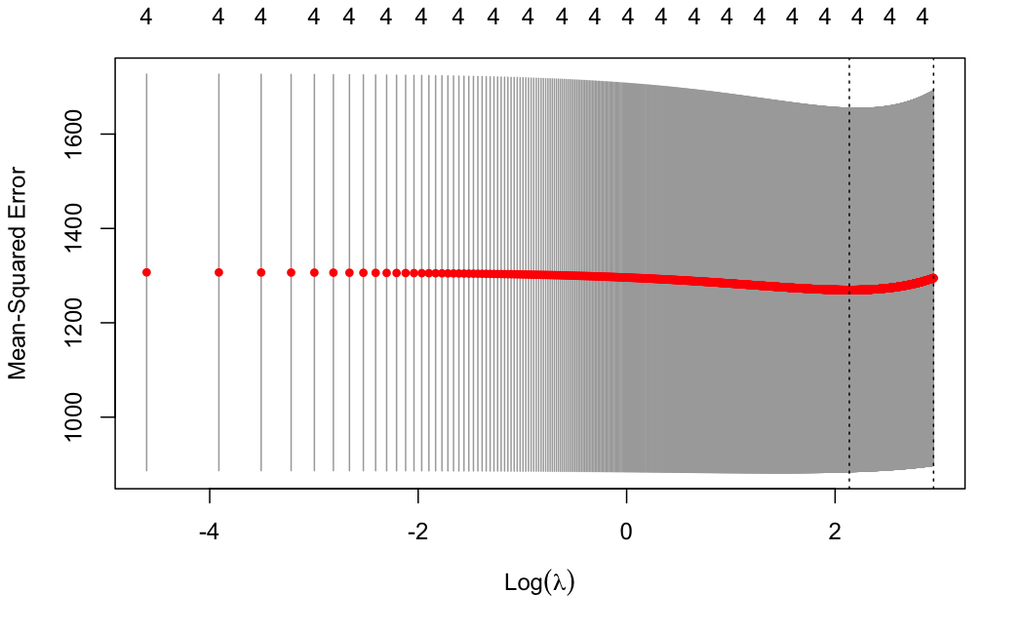

```r
#produce plot of test MSE by lambda value
plot(cv_model)
```

```r
best_model <- glmnet(x, y, alpha = 0, lambda = best_lambda)
coef(best_model)
```

```
5 x 1 sparse Matrix of class "dgCMatrix"
                    s0
(Intercept) 477.053786
mpg          -3.299354
wt           19.982582
drat         -0.518886
qsec        -18.292763
```

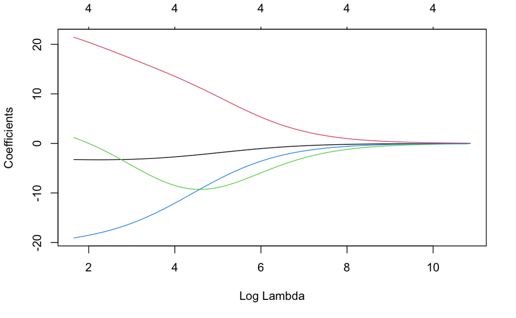

```r
#produce Ridge trace plot
plot(model, xvar = "lambda")
```

```r
#use fitted best model to make predictions
y_predicted <- predict(model, s = best_lambda, newx = x)

#find SST and SSE
sst <- sum((y - mean(y))^2)
sse <- sum((y_predicted - y)^2)

#find R-Squared
rsq <- 1 - sse/sst
rsq
```

```
[1] 0.8017026
```

Caso tonnage tiempo

```r
y <- df$Time
df$unos = rep(1, nrow(df))
#define matrix of predictor variables
x <- data.matrix(df[, c('Tonnage', "unos")])

#fit ridge regression model
modelRidge <- glmnet(x, y, alpha = 0)
#Lasso
modelLasso <- glmnet(x, y, alpha = 1)

#view summary of model
summary(modelRidge)
```

```
          Length Class     Mode
a0        100    -none-    numeric
beta      200    dgCMatrix S4
df        100    -none-    numeric
dim         2    -none-    numeric
lambda    100    -none-    numeric
dev.ratio 100    -none-    numeric
nulldev     1    -none-    numeric
npasses     1    -none-    numeric
jerr        1    -none-    numeric
offset      1    -none-    logical
call        4    -none-    call
nobs        1    -none-    numeric
```

```r
summary(modelLasso)
```

```
          Length Class     Mode
a0         55    -none-    numeric
beta      110    dgCMatrix S4
df         55    -none-    numeric
dim         2    -none-    numeric
lambda     55    -none-    numeric
dev.ratio  55    -none-    numeric
nulldev     1    -none-    numeric
npasses     1    -none-    numeric
jerr        1    -none-    numeric
offset      1    -none-    logical
call        4    -none-    call
nobs        1    -none-    numeric
```

[output not shown]

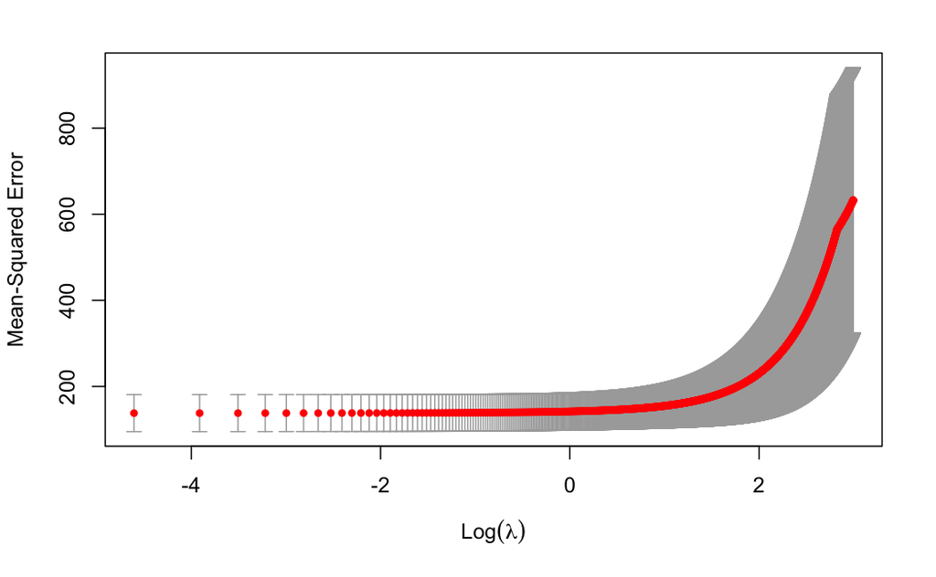

```r
plot(cv_modelLasso)
```

[output not shown]

MODELO LINEAL CLASE

```r
# ESTIMAR COPEFICIENTES
#cargo los datos
datos<-cars
names(datos)
```

```
[1] "speed" "dist"
```

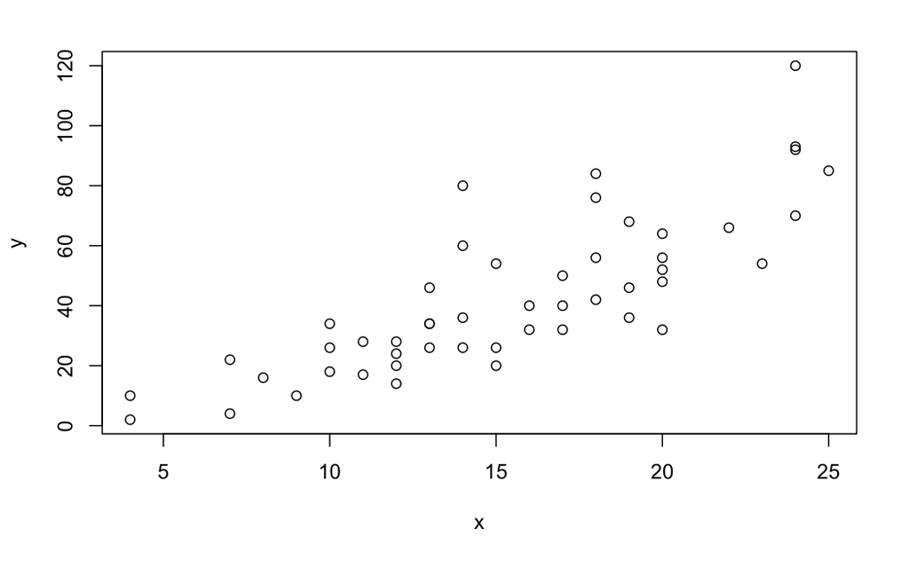

```r
#defino las variables
x<-datos$speed #velocidad del auto
y<-datos$dist #distancia requerida de frenado

plot(x,y)
```

```r
# armamos a mano la matriz de diseño
X<-cbind(rep(1,length(x)),x)

#calculamos usando la formula
beta_sombrero<-solve(t(X)%*%X)%*%t(X)%*%y

beta_sombrero0<-beta_sombrero[1]
beta_sombrero1<-beta_sombrero[2]

#graficamos la recta
plot(x,y,pch=20)
abline(beta_sombrero,col="dodgerblue3", lwd=2)#, lty=2)
```

```r
#superponemos las estimaciones de nuestros puntos de diseño
y_sombrero<-beta_sombrero0+beta_sombrero1*x
points(x,y_sombrero,col="orange", pch=18)


# estimamos sigma^2

sum((y-y_sombrero)^2)/(length(x)-2)
```

```
[1] 236.5317
```

```r
# para agregar mas covariables

x2<-x^2
reg2<-lm(y~x+x2)
summary(reg2)
```

```
Call:
lm(formula = y ~ x + x2)

Residuals:
    Min      1Q  Median      3Q     Max
-28.720  -9.184  -3.188   4.628  45.152

Coefficients:
            Estimate Std. Error t value Pr(>|t|)
(Intercept)  2.47014   14.81716   0.167    0.868
x            0.91329    2.03422   0.449    0.656
x2           0.09996    0.06597   1.515    0.136

Residual standard error: 15.18 on 47 degrees of freedom
Multiple R-squared:  0.6673,    Adjusted R-squared:  0.6532
F-statistic: 47.14 on 2 and 47 DF,  p-value: 5.852e-12
```

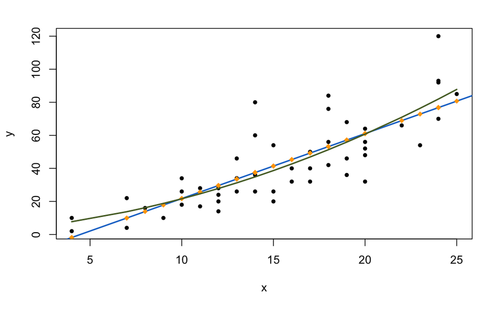

```r
#graficamos
y2<-reg2$coefficients[1]+reg2$coefficients[2]*x+reg2$coefficients[3]*x2
lines(x,y2, col="darkolivegreen", lwd=2)
```

```r
# Una no lineal
#######################################################
rm(list=ls())


## Simulacion


sigma<-sqrt(1.3)
beta.star0<- 0.1
beta.star1<- 0.025


equis<- seq(1,10, by=0.1)
set.seed(123)

z<- exp(beta.star0+beta.star1*equis*equis)
y<- z+rnorm(length(equis),0,sigma)

# con puntos
plot(equis,y,pch=20,col="grey30",xlab="x",ylim=c(0,10))

#grafico la verdadera
lines(equis,z,lwd=2,col="magenta")
```

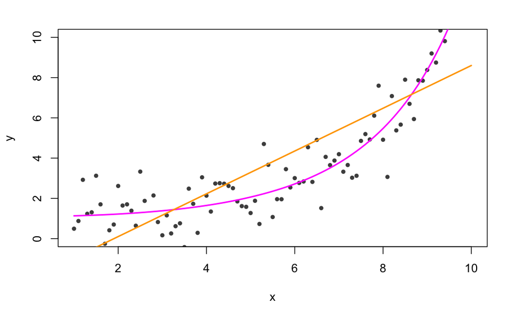

```r
###########################################################
#
#Ajusto un modelo lineal simple
#
#E(Y)= beta_0+beta_1*equis
#
###########################################################

salida.lineal<- lm(y~equis)
lines(equis,salida.lineal$fit,col="orange",lwd=2)
```

```r
###########################################################
#
#Ajusto un modelo una cuadratica
#
#E(Y)= beta_0+beta_1*equis+beta_2*equis^2
#
###########################################################

plot(equis,y,pch=20,col="grey30",xlab="x",ylim=c(0,10))
lines(equis,z,lwd=2)
```

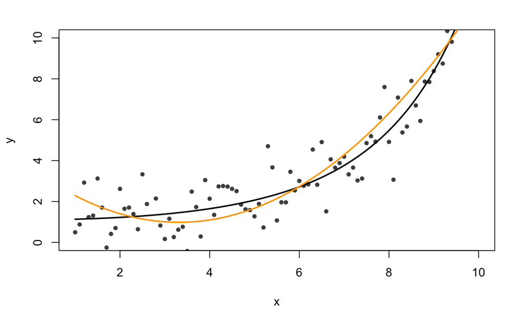

```r
salida<- lm(y~poly(equis,2,raw=TRUE))
lines(equis,salida$fit,col="orange",lwd=2)
```

```r
###########################################################
#
#Ajusto un modelo un polinomio de grado 5
#
#E(Y)= beta_0+beta_1*equis+...+beta_5*equis^5
#
###########################################################

plot(equis,y,pch=20,col="grey30",xlab="x",ylim=c(0,10))
lines(equis,z,lwd=2)
```

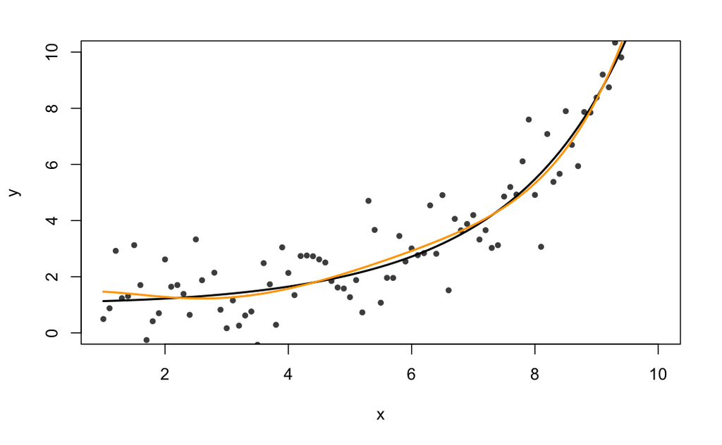

```r
salida<- lm(y~poly(equis,5,raw=TRUE))
lines(equis,salida$fit,col="orange",lwd=2)
```

```r
colores<-rainbow(9)

###########################################################
#
# Ahora lo repito 9 veces y grafico las rectas ajustadas
#
###########################################################


# sin puntos
plot(equis,y,pch=20,col="grey30",xlab="x",type="n",ylim=c(0,10))
lines(equis,z,lwd=2)
```

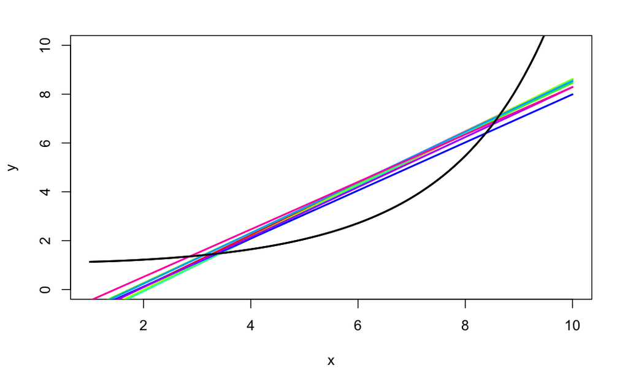

```r
set.seed(123)
for(i in 1: 9){
  z<- exp(beta.star0+beta.star1*equis*equis)
  y<- z+rnorm(length(equis),0,sigma)
  salida.lineal<- lm(y~equis)
  lines(equis,salida.lineal$fit,col=colores[i],lwd=2)
}
lines(equis,z,lwd=2)
```

```r
#points(equis,y)
###########################################################
#
# Repito 9 veces y grafico las cuadraticas ajustadas
#
###########################################################

### Ahora ajusto cuadraticas
set.seed(123)

z<- exp(beta.star0+beta.star1*equis*equis)
y<- z+rnorm(length(equis),0,sigma)

plot(equis,y,pch=20,col="grey30",xlab="x",type="n",ylim=c(0,10))
lines(equis,z,lwd=2)
```

```r
salida<- lm(y~poly(equis,2,raw=TRUE))
lines(equis,salida$fit,col=15,lwd=2)


for(i in 1:9){
  z<- exp(beta.star0+beta.star1*equis*equis)
  y<- z+rnorm(length(equis),0,sigma)
  salida<- lm(y~poly(equis,2,raw=TRUE))
  lines(equis,salida$fit,col=colores[i],lwd=2)
}
```

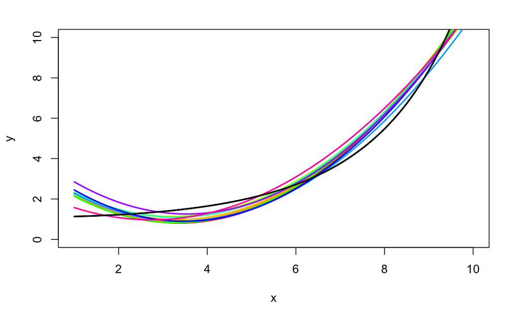

```r
lines(equis,z,lwd=2)
```

```r
#points(equis,y)

###########################################################
#
# 9 veces y grafico los polinomio de grado 5 ajustados
#
###########################################################

set.seed(123)

z<- exp(beta.star0+beta.star1*equis*equis)
y<- z+rnorm(length(equis),0,sigma)

plot(equis,y,pch=20,col="grey30",xlab="x",type="n",ylim=c(-1,10))
lines(equis,z,lwd=2)
```

```r
salida<- lm(y~poly(equis,5,raw=TRUE))
lines(equis,salida$fit,col="orange",lwd=2)

for(i in 1: 9){
  z<- exp(beta.star0+beta.star1*equis*equis)
  y<- z+rnorm(length(equis),0,sigma)
  salida<- lm(y~poly(equis,5,raw=TRUE))
  lines(equis,salida$fit,col=colores[i],lwd=2)
}
```

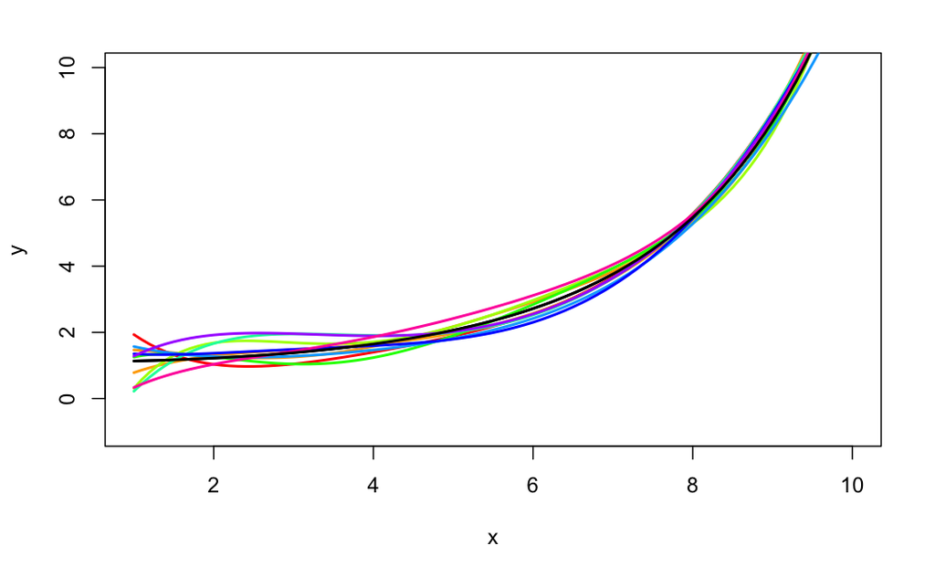

```r
lines(equis,z,lwd=2)
```

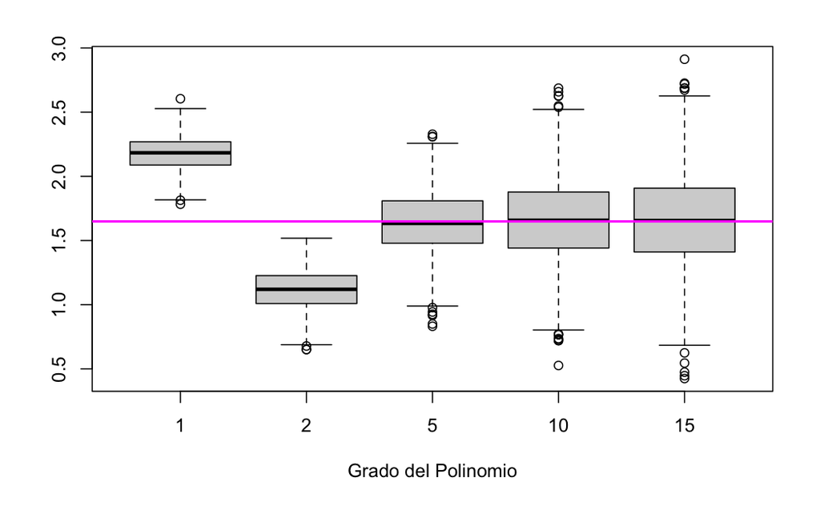

```r
###########################################################
#
# Vamos a predecir con los distintos ajustes en x_o=4
# Repetimos Nrep=1000 veces
#
###########################################################
Nrep<- 1000
set.seed(123)

pred1<-pred2<-pred5<-pred10<-pred15<-c()



equis.new<- data.frame(equis=c(4))

for(i in 1: Nrep){
  z<- exp(beta.star0+beta.star1*equis*equis)
  y<- z+rnorm(length(equis),0,sigma)
  salida1<- lm(y~equis)
  salida2<- lm(y~poly(equis,2,raw=TRUE))
  salida5<- lm(y~poly(equis,5,raw=TRUE))
  salida10<- lm(y~poly(equis,10,raw=TRUE))
  salida15<- lm(y~poly(equis,15,raw=TRUE))
  pred1<-c(pred1,predict(salida1,newdata=equis.new))
  pred2<-c(pred2,predict(salida2,newdata=equis.new))
  pred5<-c(pred5,predict(salida5,newdata=equis.new))
  pred10<-c(pred10,predict(salida10,newdata=equis.new))
  pred15<-c(pred15,predict(salida15,newdata=equis.new))
}
boxplot(pred1,pred2,pred5,pred10,pred15,names=c("1","2","5","10","15"),xlab="Grado del Polinomio")
abline(h=exp(beta.star0+beta.star1*4*4),lwd=2,col="magenta")
```

```r
NA
NA
NA
NA
```

REGULARIZACION